# FinalProject3_Submission1

Team info

**Project Title: "The Impact of Climate Change on Hurricane Frequency, Intensity, and Economic Costs in the Florida Gulf Region"**

Team name: Group 11

Team member names and PIDs: Anya Beichner (anya23), Himaja Bathula (hbathula), Sophia Chukka (sophia05), Varsha Manickam (varshamanickam21)

Project introduction

**Initial description of the project topic:**

```
This project aims to examine the impact of climate change on the frequency, intensity, and
economic consequences of hurricanes in the Gulf of Mexico and Florida region. By leveraging
historical hurricane data alongside climate data, we seek to explore how rising global
temperatures contribute to stronger hurricanes and how this has evolved over time.
Additionally, the socioeconomic impact of hurricanes—such as damage costs, human displacement,
and changes in hurricane preparedness—will be analyzed.
```

**Potential research questions you plan to address:**

```
- How have the frequency and intensity of hurricanes changed over the past few decades, and
   what role does climate change play in these trends?

- Is there a correlation between rising sea surface temperatures and the increasing power of
   hurricanes (specifically in categories 4 and 5)?

- How has the economic cost of hurricanes (e.g., property damage, insurance claims,
   infrastructure loss) evolved as a result of stronger storms?

- Which regions are becoming more vulnerable due to climate change?
```

**Description of potential source data that would be relevant (including links or references if possible):** - Hurricane Data: NOAA National Hurricane Center, IBTrACS (International Best Track Archive for Climate Stewardship) - Climate Data: NASA EarthData, NOAA Climate Data - Economic Impact Data: EM-DAT (International Disaster Database), National Centers for Environmental Information (NCEI) - Sea Surface Temperature Data: NOAA Optimum Interpolation SST

**Anya: Wind Intensity over Time**

```python
import requests
from bs4 import BeautifulSoup
url = 'https://coast.noaa.gov/hurricanes/api/v1/search/stormsByIDs'

header = {'User-Agent':'Mozilla/5.0 (Windows NT 10.0; Win64; x64) AppleWebKit/537.36 (KHTML, like Gecko) Chrome/130.0.0.0 Safari/537.36'}
payload = {"stormIDs":
           "1950231N12306,1953251N18295,1955255N19294,1956222N13313,1975256N18306,1979241N11335,1981250N15306,1984311N15291,1989254N13340,1995256N12309,1996248N15319,1998259N10335,2000233N12316,2004258N16300,2007297N18300,2011233N15301,2022257N16312,2021222N14301,2020233N14313,2017260N12310,2017242N16333,2014210N10323,1949246N19295,1940219N19295,1933206N14306,1932269N17303,1931252N15307"}

# Send an HTTP GET request to the URL
response = requests.post(url, headers=header, json=payload)
```

```python
data = response.json()

import json
print(json.dumps(data, indent=4))
```

[output not shown]

[output cut: 978 more lines]

[output not shown]

```python
#Loop through each storm and print relevant details
storms = data['data']['storms']
for storm in storms:
    storm_id = storm['stormID']
    name = storm['name']
    category = storm['category']
    max_wind_speed = storm['maxWindSpeed']
    min_pressure = storm['minPressure']
    date_range = storm['dateRange']

# Printing out storm details
    print(f"Storm ID: {storm_id}")
    print(f"Name: {name}")
    print(f"Category: {category}")
    print(f"Max Wind Speed: {max_wind_speed} mph")
    print(f"Min Pressure: {min_pressure} mb")
    print(f"Date Range: {date_range}")
    print("-" * 40)
```

```
Storm ID: 1931252N15307
Name: UNNAMED 1931
Category: H2
Max Wind Speed: 85 mph
Min Pressure: 987 mb
Date Range: Sep 08, 1931 to Sep 16, 1931
----------------------------------------
Storm ID: 1932269N17303
Name: UNNAMED 1932
Category: H4
Max Wind Speed: 125 mph
Min Pressure: 943 mb
Date Range: Sep 25, 1932 to Oct 02, 1932
----------------------------------------
Storm ID: 1933206N14306
Name: UNNAMED 1933
Category: H1
Max Wind Speed: 80 mph
Min Pressure: 975 mb
Date Range: Jul 24, 1933 to Aug 05, 1933
----------------------------------------
Storm ID: 1940219N19295
Name: UNNAMED 1940
Category: H2
Max Wind Speed: 85 mph
Min Pressure: 972 mb
Date Range: Aug 05, 1940 to Aug 14, 1940
----------------------------------------
Storm ID: 1949246N19295
Name: UNNAMED 1949
Category: H3
Max Wind Speed: 110 mph
Min Pressure: 974 mb
Date Range: Sep 03, 1949 to Sep 11, 1949
----------------------------------------
Storm ID: 1950231N12306
Name: BAKER 1950
Category: H2
Max Wind Speed: 90 mph
Min Pressure: 979 mb
```

[output cut: 134 more lines]

```
----------------------------------------
Storm ID: 2021222N14301
Name: FRED 2021
Category: TS
Max Wind Speed: 55 mph
Min Pressure: 991 mb
Date Range: Aug 09, 2021 to Aug 20, 2021
----------------------------------------
Storm ID: 2022257N16312
Name: FIONA 2022
Category: H4
Max Wind Speed: 120 mph
Min Pressure: 931 mb
Date Range: Sep 14, 2022 to Sep 27, 2022
----------------------------------------
```

[figure not shown]

[figure not shown]

```python
from datetime import datetime
import matplotlib.pyplot as plt

# Extract storms data
storms = data['data']['storms']

# Prepare data for plotting
storm_dates = []
max_wind_speeds = []
storm_categories = []
storm_names = []

for storm in storms:
    storm_id = storm['stormID']
    name = storm['name']
    category = storm['category']
    max_wind_speed = storm['maxWindSpeed']
    min_pressure = storm['minPressure']
    date_range = storm['dateRange']

    # Extract start date from dateRange (assuming it's in format 'Sep 08, 1931 to Sep 16, 1931')
    start_date_str = date_range.split(' to ')[0]  # Get the start date part
    start_date = datetime.strptime(start_date_str, '%b %d, %Y')  # Parse date using correct format

    storm_dates.append(start_date)
    max_wind_speeds.append(max_wind_speed)
    storm_categories.append(category)
    storm_names.append(name)

# Plotting Max Wind Speed over Time
plt.figure(figsize=(10, 6))
plt.plot(storm_dates, max_wind_speeds, color='r', marker='o', linestyle='-', label='Max Wind Speed (mph)')
plt.title("Max Wind Speed of Storms Over Time")
plt.xlabel("Year")
plt.ylabel("Max Wind Speed (mph)")
plt.xticks(rotation=45)
plt.grid(True)
plt.tight_layout()
plt.legend()
plt.show()

# Plotting Category over Time
plt.figure(figsize=(10, 6))
plt.scatter(storm_dates, storm_categories, color='b', marker='o', label='Category')
plt.title("Storm Category Over Time")
plt.xlabel("Year")
plt.ylabel("Category")
plt.xticks(rotation=45)
plt.yticks(range(1, 6), ['1', '2', '3', '4', '5'])  # Assuming category is between 1 and 5
plt.grid(True)
plt.tight_layout()
plt.legend()
plt.show()
```

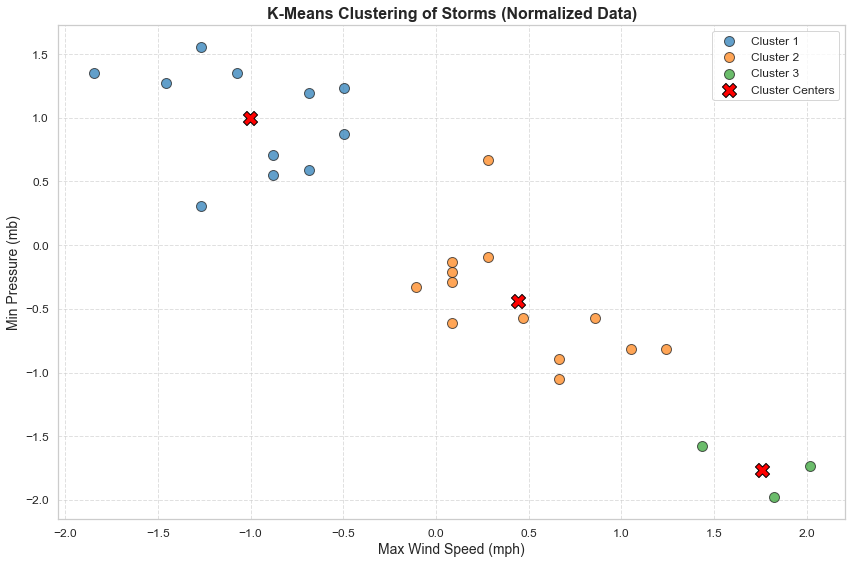

```python
from sklearn.cluster import KMeans
from sklearn.preprocessing import StandardScaler
import numpy as np
import matplotlib.pyplot as plt
import seaborn as sns

# Set a seaborn style for a polished, minimalistic look
sns.set(style="whitegrid")

# Example: Extracting relevant features (max wind speed and minimum pressure)
features = np.array([[storm['maxWindSpeed'], storm['minPressure']] for storm in storms])

# Normalize the features (important for clustering to prevent scale issues)
scaler = StandardScaler()
normalized_features = scaler.fit_transform(features)

# Perform K-Means clustering (let's assume we want to find 3 clusters)
kmeans = KMeans(n_clusters=3, random_state=0)
clusters = kmeans.fit_predict(normalized_features)

# Add cluster labels to each storm for easy identification
for i, storm in enumerate(storms):
    storm['cluster'] = clusters[i]

# Create a scatter plot to visualize the clusters
plt.figure(figsize=(12, 8))

# Define a list of simple, distinct colors for the clusters
colors = ['#1f77b4', '#ff7f0e', '#2ca02c']  # Blue, Orange, Green

# Plot the points with colors based on the cluster assignment
for i in range(3):  # Loop through each cluster
    cluster_points = normalized_features[clusters == i]
    plt.scatter(cluster_points[:, 0], cluster_points[:, 1],
                c=colors[i], label=f'Cluster {i+1}', s=100, edgecolors='k', alpha=0.7)

# Plot the cluster centers in the normalized space
centers = kmeans.cluster_centers_
plt.scatter(centers[:, 0], centers[:, 1], c='red', marker='X', s=200, label='Cluster Centers', edgecolors='black')

# Add labels and title with better formatting
plt.title("K-Means Clustering of Storms (Normalized Data)", fontsize=16, fontweight='bold')
plt.xlabel("Max Wind Speed (mph)", fontsize=14)
plt.ylabel("Min Pressure (mb)", fontsize=14)
plt.xticks(fontsize=12)
plt.yticks(fontsize=12)
plt.legend(fontsize=12)
plt.grid(True, linestyle='--', alpha=0.6)

# Display the plot
plt.tight_layout()
plt.show()
```

**Hima + Varsha: Florida Sea Levels Analysis**

```python
import requests
from bs4 import BeautifulSoup
import pandas as pd

# URL of the CSV file with sea level trend data
url = "https://tidesandcurrents.noaa.gov/sltrends/data/USStationsLinearSeaLevelTrends.csv"

# Load the CSV data directly into a pandas DataFrame
data = pd.read_csv(url)

# Clean up the column names by removing any extra spaces
data.columns = data.columns.str.strip()

# Filter the data to only include stations in Florida (where "Station Name" contains "FL")
florida_data = data[data['Station Name'].str.contains("FL")]

# Print the filtered data for Florida to see what we’re working with
print(florida_data)
```

```
    Station ID                      Station Name  First Year  Last Year  \
60     8720030              Fernandina Beach, FL        1897       2023
61     8720218                       Mayport, FL        1928       2023
62     8721604  Trident Pier, Port Canaveral, FL        1994       2023
63     8722670               Lake Worth Pier, FL        1970       2023
64     8723214                  Virginia Key, FL        1931       2023
65     8723970                      Vaca Key, FL        1971       2023
66     8724580                      Key West, FL        1913       2023
67     8725110                        Naples, FL        1965       2023
68     8725520                    Fort Myers, FL        1965       2023
69     8726384                  Port Manatee, FL        1976       2023
70     8726520                St. Petersburg, FL        1947       2023
71     8726674                      East Bay, FL        1976       2023
72     8726724              Clearwater Beach, FL        1973       2023
73     8727520                     Cedar Key, FL        1914       2023
```

[output cut: 44 more lines]

```python
#print(florida_data.columns.tolist())
```

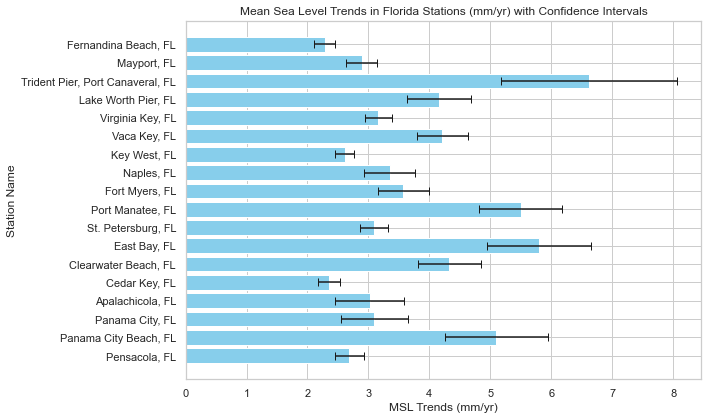

```python
# Set up the figure size for the horizontal bar chart
plt.figure(figsize=(10, 6))

# Create a horizontal bar chart for MSL trends with error bars for confidence intervals
plt.barh(
    florida_data["Station Name"],  # Station names on the y-axis
    florida_data["MSL Trends (mm/yr)"],  # MSL trends on the x-axis
    xerr=florida_data["+/- 95% CI (mm/yr)"],  # Confidence intervals as error bars
    color='skyblue',  # Bar color
    capsize=4  # Add caps to the error bars
)

# Label the x-axis and y-axis
plt.xlabel("MSL Trends (mm/yr)")
plt.ylabel("Station Name")

# Add a title to explain what the chart shows
plt.title("Mean Sea Level Trends in Florida Stations (mm/yr) with Confidence Intervals")

# Flip the y-axis to list stations from top to bottom
plt.gca().invert_yaxis()

# Adjust the layout to make it look better
plt.tight_layout()

# Display the chart
plt.show()
```

Sea Level Trends Across Florida Stations:

The graph shows how quickly the sea level is rising at different stations in Florida.

For example, Trident Pier, Port Canaveral has the fastest rate of sea level rise ( approximately 6.6 mm/year) while Fernandina Beach has the slowest (~2.28 mm/year).

Comparing Stations:

Stations like East Bay, Port Manatee, and Panama City Beach also show high rates of sea level rise (>5 mm/year), which might make them more vulnerable to flooding and other issues.

Stations like Key West and Cedar Key show slower increases, which might mean they are less affected for now.

Uncertainty in Measurements:

The confidenec intervals on each bar show how reliable the data is. Some of the stations like Trident Pier have bigger confidende intervals showing that there’s more uncertainty in the measurement. Other stations like St. Petersburg have smaller CIs indicating the measurements are more consistent.

Why This Matters:

Areas with faster sea level rise (like Trident Pier and East Bay) could face bigger challenges with flooding or erosion so they might need more attention. The differences in sea level rise could be caused by things like the location of the station, human activity, or natural coastal features. It's also interesting to see how big of a difference there is the confidence intervals at the idfferent stations within the same state too. Exploring why this is the case would be an interesting follow-up question

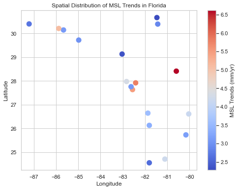

```python
import matplotlib.pyplot as plt

# Set up the figure size for the scatter plot
plt.figure(figsize=(8, 6))

# Create a scatter plot showing latitude and longitude, with colors based on MSL Trends
plt.scatter(florida_data["Longitude"], florida_data["Latitude"],
            c=florida_data["MSL Trends (mm/yr)"], cmap="coolwarm", s=100)

# Add a color bar to explain what the colors represent
plt.colorbar(label="MSL Trends (mm/yr)")

# Label the x-axis and y-axis
plt.xlabel("Longitude")
plt.ylabel("Latitude")

# Add a title to explain what the plot is about
plt.title("Spatial Distribution of MSL Trends in Florida")

# Add grid lines to make the plot easier to read
plt.grid(True)

# Show the plot
plt.show()
```

What This Graph Tells Us:

Where Sea Levels Are Rising Fastest:

The redder points like Trident Pierand Port Canaveral, seem to have the fastest sea level rise (~6.6 mm/year). These are the areas that might be more at risk for flooding or erosion.

On the other hand, blue points like Fernandina Beach show much slower sea level rise (~2.28 mm/year).

Geographic Patterns:

Why This is Helpful:

This graph makes it easy to compare stations and spot patterns that aren’t as obvious in other charts. For example, we can see that stations in some regions (like near the Gulf of Mexico or Atlantic coast) have very different rates of change. It also raises interesting questions like why are some areas affected more than others? Could it be related to natural features, or is it something people are doing in those areas?

Overall:

This graph helps us connect the numbers with actual locations, which is super helpful for understanding the bigger picture. It also makes it clear which areas might need more attention when it comes to sea level rise and its effects.

**Hima + Varsha: Correlating Sea Surface Temperatures in the Gulf of Mexico with Hurricane Intensity this Past Year(2024)**

SST on the Eastern side of Gulf of Mexico Dataframe:

```python
import requests
from bs4 import BeautifulSoup
import pandas as pd


url = "https://www.ncei.noaa.gov/access/coastal-water-temperature-guide/all_table.html"


response = requests.get(url)
if response.status_code != 200:
    print(f"Couldn't load the page. Status code: {response.status_code}")
else:

    soup = BeautifulSoup(response.content, 'html.parser')

    # Look for the table with "Monthly Average Temperature (°F) for Eastern Gulf of Mexico Coast"
    target_table = None
    for table in soup.find_all('table', class_='table table-striped'):
        # Check each table for the header text we want
        header = table.find('th', string="Monthly Average Temperature (°F) for Eastern Gulf of Mexico Coast")
        if header:
            target_table = table
            break  # Stop once we find the right table

    if target_table is None:
        print("Couldn't find the target table.")
    else:
        # Manually set the column names to match the table
        headers = ["Location", "Recent Temperature (°F)", "JAN", "FEB", "MAR", "APR", "MAY", "JUN",
                   "JUL", "AUG", "SEP", "OCT", "NOV", "DEC"]


        data_rows = []


        rows = target_table.find('tbody').find_all('tr') if target_table.find('tbody') else target_table.find_all('tr')

        # Go through each row and get the data
        for row in rows:
            row_data = []
            cells = row.find_all('td')

            # Only process rows that actually have data
            if cells:
                # Get the location
                row_data.append(cells[0].text.strip())  # Location

                # Get the recent temperature (including the timestamp if it’s there)
                row_data.append(cells[1].text.strip())  # Recent Temperature

                # Get the monthly temperatures from the other cells
                for cell in cells[2:]:
                    link = cell.find('a')
                    if link:
                        # If there’s a link, get the temperature value from the text
                        temp_value = link.text.strip()
                        row_data.append(temp_value)
                    else:
                        row_data.append('')

                # Add the row data to the list
                data_rows.append(row_data)

        # Turn the data into a DataFrame
        df = pd.DataFrame(data_rows, columns=headers)

        # Print the DataFrame to see the results
        print("Monthly Average Temperature (°F) for Eastern Gulf of Mexico Coast Data:")
        print(df)

        # Save the data to a CSV file (just in case we want to use it later)
        df.to_csv('eastern_gulf_mexico_monthly_avg_temperature.csv', index=False)
```

```
Monthly Average Temperature (°F) for Eastern Gulf of Mexico Coast Data:
                                             Location  \
0                WEST TAMPA - 112 NM WNW of Tampa, FL
1   LUKE OFFSHORE TEST PLATFORM - 63 NM South of D...
2                                     Broad River, FL
3                                   Butternut Key, FL
4                                       Bob Allen, FL
5                                Blackwater Sound, FL
6                                      Cane Patch, FL
7                                      Cannon Bay, FL
8                                        Duck Key, FL
9                                  Gunboat Island, FL
10                                 Garfield Bight, FL
11                                  Highway Creek, FL
12                                    Johnson Key, FL
```

[output cut: 114 more lines]

SST on the Western side of Gulf of Mexico Dataframe:

```python
import requests
from bs4 import BeautifulSoup
import pandas as pd


url = "https://www.ncei.noaa.gov/access/coastal-water-temperature-guide/all_table.html"


response = requests.get(url)
if response.status_code != 200:
    print(f"Couldn't load the page. Status code: {response.status_code}")
else:

    soup = BeautifulSoup(response.content, 'html.parser')

    # Look for the table with "Monthly Average Temperature (°F) for Western Gulf of Mexico Coast"
    target_table = None
    for table in soup.find_all('table', class_='table table-striped'):

        header = table.find('th', string="Monthly Average Temperature (°F) for Western Gulf of Mexico Coast")
        if header:
            target_table = table
            break

    if target_table is None:
        print("Couldn't find the target table.")
    else:

        headers = ["Location", "Recent Temperature (°F)", "JAN", "FEB", "MAR", "APR", "MAY", "JUN",
                   "JUL", "AUG", "SEP", "OCT", "NOV", "DEC"]


        data_rows = []


        rows = target_table.find('tbody').find_all('tr') if target_table.find('tbody') else target_table.find_all('tr')


        for row in rows:
            row_data = []
            cells = row.find_all('td')

            # Only process rows that actually have data
            if cells:
                # Get the location
                row_data.append(cells[0].text.strip())  # Location

                # Get the recent temperature (including the timestamp if it’s there)
                row_data.append(cells[1].text.strip())  # Recent Temperature

                # Get the monthly temperatures from the other cells
                for cell in cells[2:]:
                    link = cell.find('a')
                    if link:

                        temp_value = link.text.strip()
                        row_data.append(temp_value)
                    else:
                        row_data.append('')

                # Add the row data to the list
                data_rows.append(row_data)

        # Turn the data into a DataFrame
        df = pd.DataFrame(data_rows, columns=headers)


        print("Monthly Average Temperature (°F) for Western Gulf of Mexico Coast Data:")
        print(df)


        df.to_csv('western_gulf_mexico_monthly_avg_temperature.csv', index=False)
```

```
Monthly Average Temperature (°F) for Western Gulf of Mexico Coast Data:
                                             Location  \
0          WEST GULF - 207 NM East of Brownsville, TX
1   CORPUS CHRISTI, TX - 60NM SSE of Corpus Christ...
2         BAY OF CAMPECHE - 214 NM NE of Veracruz, MX
3                                       Pilottown, LA
4                  Pilots Station East, S.W. Pass, LA
5                                     Shell Beach, LA
6                               New Canal Station, LA
7                                      Carrollton, LA
8                       West Bank 1, Bayou Gauche, LA
9                      Berwick, Atchafalaya River, LA
10                            LAWMA, Amerada Pass, LA
11                                   Lake Charles, LA
12                                  Bulk Terminal, LA
```

[output cut: 60 more lines]

Combined Gulf of Mexico Regions Dataframe:

```python
import pandas as pd


eastern_df = pd.read_csv('eastern_gulf_mexico_monthly_avg_temperature.csv')


western_df = pd.read_csv('western_gulf_mexico_monthly_avg_temperature.csv')


merged_df = pd.concat([eastern_df, western_df], ignore_index=True)


print("Gulf of Mexico Merged DataFrame")
print(merged_df)


merged_df.to_csv('gulf_of_mexico_monthly_avg_temperature.csv', index=False)
```

```
Gulf of Mexico Merged DataFrame
                                             Location  \
0                WEST TAMPA - 112 NM WNW of Tampa, FL
1   LUKE OFFSHORE TEST PLATFORM - 63 NM South of D...
2                                     Broad River, FL
3                                   Butternut Key, FL
4                                       Bob Allen, FL
..                                                ...
59                 Matagorda Bay Entrance Channel, TX
60                                       Rockport, TX
61                                   Port Aransas, TX
62                                 Port Mansfield, TX
63                                    Port Isabel, TX

       Recent Temperature (°F)   JAN   FEB   MAR   APR   MAY   JUN   JUL  \
```

[output cut: 26 more lines]

Hurricane Intensity Data Frame:

```python
import requests
from bs4 import BeautifulSoup
import pandas as pd

# Define the URL of the webpage
url = "https://tropical.atmos.colostate.edu/Realtime/index.php?loc=northatlantic"


response = requests.get(url)
if response.status_code != 200:
    print(f"Failed to retrieve the page. Status code: {response.status_code}")
else:

    soup = BeautifulSoup(response.content, 'html.parser')


    target_table = soup.find('table', {'id': 'info', 'class': 'sortable location'})
    if not target_table:
        print("Target table not found.")
    else:
        # Define headers based on the table
        headers = ["Year", "Storm#", "Name", "Dates TC Active", "Max Wind (kts)",
                   "MSLP (mb)", "Named Storm Days", "Hurricane Days",
                   "Major Hurricane Days", "Accumulated Cyclone Energy"]

        # Initialize a list to store data rows
        data_rows = []

        # Find all rows in the table
        rows = target_table.find('tbody').find_all('tr')

        # Extract data from each row
        for row in rows:
            row_data = []
            cells = row.find_all('td')
            if cells:

                for i, cell in enumerate(cells):
                    if i == 2:
                        link = cell.find('a')
                        if link:
                            row_data.append(link.text.strip())  # Hurricane Name
                            row_data.append(link['href'].strip())  # Link to details
                        else:
                            row_data.append(cell.text.strip())
                            row_data.append("")  # No link available
                    else:
                        row_data.append(cell.text.strip())
                # Append the row data to the list
                data_rows.append(row_data)


        headers.insert(3, "Details Link")


        df = pd.DataFrame(data_rows, columns=headers)


        # Save the data to a CSV file
        csv_filename = 'hurricane_data_with_links.csv'
        df.to_csv(csv_filename, index=False)
```

Combined Analysis - Heatmap, depicting the relationship between SST of 40 areas around the Gulf of Mexico Region with Hurricane Intensity this year (2024)

```
   Hurricane Active Months  Max Wind (mph)    ACE  Average SST (°F)
0    ALBERTO           JUN              45   1.25         83.600000
1      BERYL      JUN, JUL             145  10.00         86.583333
2      CHRIS           JUL              35   0.50         87.750000
3      DEBBY           AUG              70   5.00         87.733333
4    ERNESTO           AUG              85   7.75         87.800000
5   FRANCINE           SEP              85   3.00         83.033333
6     GORDON           SEP              40   2.25         83.866667
7     HELENE           SEP             120   3.25         88.400000
8      ISAAC           SEP              90   4.50         84.233333
9      JOYCE           SEP              45   2.50         86.433333
10      KIRK           OCT             125   7.25         81.800000
11    LESLIE           OCT              90   9.50         82.500000
12    MILTON           OCT             155   5.00         82.200000
13    NADINE           OCT              45   0.75         76.500000
14     OSCAR           OCT              75   3.25         78.500000
15     PATTY           NOV              55   2.50         73.800000
16    RAFAEL           NOV             105   6.00         69.633333
17      SARA           NOV              45   3.00         77.066667
```

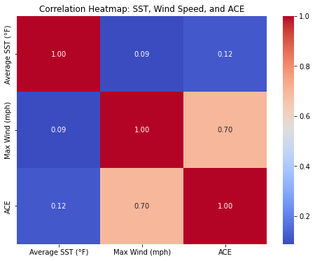

```python
import pandas as pd
import matplotlib.pyplot as plt
import seaborn as sns


sst_data = pd.read_csv('gulf_of_mexico_monthly_avg_temperature.csv')


hurricane_data = [
    {"Name": "ALBERTO", "Active Months": ["JUN"], "Max Wind": 45, "ACE": 1.25, "Locations": ["WEST TAMPA - 112 NM WNW of Tampa, FL", "Broad River, FL"]},
    {"Name": "BERYL", "Active Months": ["JUN", "JUL"], "Max Wind": 145, "ACE": 10.00, "Locations": ["Fort Myers, FL", "Naples, Gulf of Mexico, FL", "Clearwater Beach, FL"]},
    {"Name": "CHRIS", "Active Months": ["JUL"], "Max Wind": 35, "ACE": 0.50, "Locations": ["Port Manatee, FL", "St. Petersburg, Tampa Bay, FL"]},
    {"Name": "DEBBY", "Active Months": ["AUG"], "Max Wind": 70, "ACE": 5.00, "Locations": ["Blackwater Sound, FL", "Bob Allen, FL", "Broad River, FL"]},
    {"Name": "ERNESTO", "Active Months": ["AUG"], "Max Wind": 85, "ACE": 7.75, "Locations": ["East Bay, FL", "Venice, FL", "Naples, Gulf of Mexico, FL"]},
    {"Name": "FRANCINE", "Active Months": ["SEP"], "Max Wind": 85, "ACE": 3.00, "Locations": ["Pensacola, FL", "Mobile State Docks, AL", "Bay Waveland Yacht Club, MS"]},
    {"Name": "GORDON", "Active Months": ["SEP"], "Max Wind": 40, "ACE": 2.25, "Locations": ["Port Manatee, FL", "Pascagoula NOAA Lab, MS", "Apalachicola, FL"]},
    {"Name": "HELENE", "Active Months": ["SEP"], "Max Wind": 120, "ACE": 3.25, "Locations": ["Garfield Bight, FL", "Highway Creek, FL"]},
    {"Name": "ISAAC", "Active Months": ["SEP"], "Max Wind": 90, "ACE": 4.50, "Locations": ["Naples, Gulf of Mexico, FL", "Pensacola, FL", "Coast Guard Sector Mobile, AL"]},
    {"Name": "JOYCE", "Active Months": ["SEP"], "Max Wind": 45, "ACE": 2.50, "Locations": ["Broad River, FL", "Little Madeira, FL", "Little Rabbit Key, FL"]},
    {"Name": "KIRK", "Active Months": ["OCT"], "Max Wind": 125, "ACE": 7.25, "Locations": ["Willy Willy, FL", "Watson Place, FL", "Bob Allen, FL"]},
    {"Name": "LESLIE", "Active Months": ["OCT"], "Max Wind": 90, "ACE": 9.50, "Locations": ["Cannon Bay, FL", "Lostmans River, FL", "Whipray Basin, FL"]},
    {"Name": "MILTON", "Active Months": ["OCT"], "Max Wind": 155, "ACE": 5.00, "Locations": ["Broad River, FL", "Blackwater Sound, FL", "Duck Key, FL"]},
    {"Name": "NADINE", "Active Months": ["OCT"], "Max Wind": 45, "ACE": 0.75, "Locations": ["Pascagoula NOAA Lab, MS", "Mobile State Docks, AL"]},
    {"Name": "OSCAR", "Active Months": ["OCT"], "Max Wind": 75, "ACE": 3.25, "Locations": ["Pensacola, FL", "East Bay, FL", "Clearwater Beach, FL"]},
    {"Name": "PATTY", "Active Months": ["NOV"], "Max Wind": 55, "ACE": 2.50, "Locations": ["St. Petersburg, Tampa Bay, FL", "Old Port Tampa, FL"]},
    {"Name": "RAFAEL", "Active Months": ["NOV"], "Max Wind": 105, "ACE": 6.00, "Locations": ["Venice, FL", "Clearwater Beach, FL", "Mobile State Docks, AL"]},
    {"Name": "SARA", "Active Months": ["NOV"], "Max Wind": 45, "ACE": 3.00, "Locations": ["Little Rabbit Key, FL", "Taylor River, FL", "Willy Willy, FL"]},
]


hurricane_sst_analysis = []

for hurricane in hurricane_data:
    hurricane_name = hurricane["Name"]
    active_months = hurricane["Active Months"]
    max_wind = hurricane["Max Wind"]
    ace = hurricane["ACE"]
    locations = hurricane["Locations"]


    location_data = sst_data[sst_data['Location'].isin(locations)]


    avg_sst = 0
    if not location_data.empty:
        month_columns = [month.upper() for month in active_months]
        avg_sst = location_data[month_columns].mean().mean()


    hurricane_sst_analysis.append({
        "Hurricane": hurricane_name,
        "Active Months": ", ".join(active_months),
        "Max Wind (mph)": max_wind,
        "ACE": ace,
        "Average SST (°F)": avg_sst
    })



hurricane_sst_df = pd.DataFrame(hurricane_sst_analysis)


print(hurricane_sst_df)


hurricane_sst_df.to_csv('hurricane_sst_analysis.csv', index=False)

corr_data = hurricane_sst_df[['Average SST (°F)', 'Max Wind (mph)', 'ACE']].corr()

plt.figure(figsize=(8, 6))
sns.heatmap(corr_data, annot=True, cmap='coolwarm', fmt=".2f")
plt.title('Correlation Heatmap: SST, Wind Speed, and ACE')
plt.show()
```

Heatmap Analysis:

Monthly SST average was performed for areas around the florida/gulf of mexico that were in the "path" of 2024 hurricanes.

-Between SST and Max Wind (0.09): Correlation is very low indicating that SST does not directly impact wind intensity

-Between Max Wind and ACE (0.70): Strong positive correlation which makes sense because stronger hurricanes with higher wind speeds tend to accumulate more cyclone energy

-Between SST and ACE (0.12): Correlation is weakly positive indicating that increasing SSTs may have an impact on cyclone energy, but is probably not the most significant factor (other factors at play).

```python
import requests   # pip3 install requests
import pandas as pd
import matplotlib.pyplot as plt
import os
url = 'https://www.ncei.noaa.gov/access/billions/state-summary/FL'
header = {'user-agent': 'Mozilla/5.0 (Macintosh; Intel Mac OS X 10_15_7) AppleWebKit/605.1.15 (KHTML, like Gecko) Version/17.5 Safari/605.1.15'}
page = requests.get(url, headers=header)
page.reason
```

```
'OK'
```

```python
page.text
```

[output not shown]

```python
### to see what you fetched...
f = open('socioeconomicdata.html','w')
f.write(page.text)
f.close()
```

```python
import bs4
soup = bs4.BeautifulSoup(page.text,'html5lib')
```

```python
table = soup.find('table', {'class': 'events-table'})
#table
```

```python
events = []
for tr in table.find('tbody').find_all('tr'):  # Iterate through all rows in the tbody
    event_cell = tr.find('td', {'class': 'event-name'})  # Find the 'event-name' column
    if event_cell:  # If event_cell exists, extract the text
        event = event_cell.text.strip()
        events.append(event)

# Print the list of events
print("Extracted Events:")
for event in events:
    print(event)

# Convert to a DataFrame for further analysis if needed
df = pd.DataFrame(events, columns=['Event'])
print("\nEvent DataFrame:")
print(df)
```

```
Extracted Events:
Hurricane MiltonAugust 2024
Hurricane HeleneSeptember 2024
Hurricane DebbyAugust 2024
Southern DerechoMay 2024
Southern Severe WeatherMay 2024
Central, Southern, Southeastern Tornado OutbreakMay 2024
Southern and Eastern Severe WeatherApril 2024
Central Tornado Outbreak and Eastern Severe WeatherApril 2024
Southern Severe WeatherFebruary 2024
Southern Tornado Outbreak and East Coast StormJanuary 2024
East Coast Storm and FloodingDecember 2023
Hurricane IdaliaAugust 2023
Northeastern and Eastern Severe WeatherAugust 2023
Central and Southern Severe WeatherJune 2023
Southern Severe WeatherJune 2023
Southern Severe WeatherApril 2023
Central and Southern Severe WeatherApril 2023
Fort Lauderdale Flash FloodApril 2023
Hurricane NicoleNovember 2022
Hurricane IanSeptember 2022
Southeast Tornado OutbreakApril 2022
Southern Tornado OutbreakMarch 2022
Hurricane NicholasSeptember 2021
Hurricane IdaAugust 2021
Tropical Storm FredAugust 2021
Tropical Storm ElsaJuly 2021
Tropical Storm EtaNovember 2020
Hurricane SallySeptember 2020
Hurricane IsaiasAugust 2020
South, Central and Eastern Severe WeatherMay 2020
Southern Severe WeatherApril 2020
Southeast and Eastern Tornado OutbreakApril 2020
South, East and Northeast Severe WeatherFebruary 2020
Hurricane DorianSeptember 2019
Hurricane MichaelOctober 2018
Southern and Eastern Tornadoes and Severe WeatherApril 2018
Southeastern Tornadoes and Severe WeatherMarch 2018
Hurricane IrmaSeptember 2017
Southeast Severe Weather and TornadoesApril 2017
```

[output cut: 55 more lines]

```
Event DataFrame:
                                                Event
0                         Hurricane MiltonAugust 2024
1                      Hurricane HeleneSeptember 2024
2                          Hurricane DebbyAugust 2024
3                            Southern DerechoMay 2024
4                     Southern Severe WeatherMay 2024
..                                                ...
88        Tornadoes, Severe Storms, FloodsSpring 1984
89                      Freeze/Cold WaveDecember 1983
90  Gulf States Storms and FloodingDecember 1982-J...
91  Midwest/Southeast/Northeast Winter Storm, Cold...
92                         Florida FreezeJanuary 1981

[93 rows x 1 columns]
```

```python
table = soup.find('table', {'class': 'events-table'})

end_dates = []
for tr in table.find('tbody').find_all('tr'):  # Iterate through all rows in the tbody
    end_date_cell = tr.find('td', {'class': 'end-date'})  # Find the 'end-date' cell
    if end_date_cell:  # If end_date exists, extract the text
        end_date = end_date_cell.text.strip()
        end_dates.append(end_date)

# Print the list of end dates
print("Extracted End Dates:")
for date in end_dates:
    print(date)

# Convert to a DataFrame for further analysis if needed
df = pd.DataFrame(end_dates, columns=['End Date'])
print("\nEnd Date DataFrame:")
print(df)
```

```
Extracted End Dates:
October 10, 2024
September 29, 2024
August 9, 2024
May 17, 2024
May 13, 2024
May 9, 2024
April 11, 2024
April 3, 2024
February 12, 2024
January 10, 2024
December 18, 2023
August 31, 2023
August 8, 2023
June 18, 2023
June 14, 2023
April 27, 2023
April 15, 2023
April 13, 2023
November 11, 2022
September 30, 2022
April 6, 2022
March 30, 2022
September 18, 2021
September 1, 2021
August 18, 2021
July 9, 2021
November 12, 2020
September 17, 2020
August 4, 2020
May 23, 2020
April 23, 2020
April 13, 2020
February 7, 2020
September 6, 2019
October 11, 2018
April 16, 2018
March 21, 2018
September 12, 2017
April 6, 2017
```

[output cut: 55 more lines]

```
End Date DataFrame:
              End Date
0     October 10, 2024
1   September 29, 2024
2       August 9, 2024
3         May 17, 2024
4         May 13, 2024
..                 ...
88       April 7, 1984
89   December 25, 1983
90    January 15, 1983
91    January 16, 1982
92    January 14, 1981

[93 rows x 1 columns]
```

```python
costs = []
for tr in table.find('tbody').find_all('tr'):  # Iterate through all rows in the tbody
    cost_cell = tr.find('td', {'class': 'cost'})  # Find the 'small' class (costs)
    if cost_cell:  # If cost_cell exists, extract the text
        cost = cost_cell.text.strip()
        costs.append(cost)

# Print the list of costs
print("Extracted Costs:")
for cost in costs:
    print(cost)

# Convert to a DataFrame for further analysis if needed
df = pd.DataFrame(costs, columns=['Cost'])
print("\nCost DataFrame:")
print(df)
```

```
Extracted Costs:
TBD
TBD
$2.5 CI
$1.6 CI
$1.1 CI
$6.6 CI
$2.7 CI
$2.5 CI
$1.1 CI
$2.8 CI
$1.3 CI
$3.6 CI
$1.7 CI
$3.9 CI
$4.2 CI
$1.4 CI
$1.4 CI
$1.1 CI
$1.1 CI
$118.5 CI
$1.5 CI
$1.4 CI
$1.2 CI
$84.6 CI
$1.5 CI
$1.4 CI
$1.8 CI
$8.8 CI
$5.8 CI
$1.9 CI
$1.7 CI
$4.2 CI
$1.5 CI
$2.0 CI
$31.0 CI
$1.7 CI
$1.8 CI
$64.0 CI
$1.3 CI
```

[output cut: 55 more lines]

```
Cost DataFrame:
        Cost
0        TBD
1        TBD
2    $2.5 CI
3    $1.6 CI
4    $1.1 CI
..       ...
88  $1.9* CI
89   $6.5 CI
90   $4.9 CI
91  $2.2* CI
92  $2.1* CI

[93 rows x 1 columns]
```

[figure not shown]

```python
def clean_cost(cost):
    try:
        # Remove non-numeric characters (except . and digits)
        numeric_cost = ''.join(char for char in cost if char.isdigit() or char == '.')
        return float(numeric_cost) if numeric_cost else None
    except ValueError:
        return None

# Process the data and filter invalid or TBD costs
filtered_data = [
    (date, clean_cost(cost)) for date, cost in zip(end_dates, costs) if cost.lower() != "tbd"
]

# Remove any entries where cleaning resulted in None
filtered_data = [(date, cost) for date, cost in filtered_data if cost is not None]

# Separate the filtered data into separate lists
filtered_dates, filtered_costs = zip(*filtered_data)

# Convert end_dates to a DataFrame for sorting and ensure they start from 1981
df = pd.DataFrame({'End Date': filtered_dates, 'Cost': filtered_costs})
df['End Date'] = pd.to_datetime(df['End Date'])  # Convert dates to datetime objects
df = df.sort_values(by='End Date')  # Sort by date
df = df[df['End Date'] >= "1981-01-01"]  # Filter to start from 1981

# Plotting an area chart
plt.figure(figsize=(10, 6))
plt.fill_between(df['End Date'], df['Cost'], color='lightgreen', alpha=0.5, label="Cost Over Time")
plt.plot(df['End Date'], df['Cost'], color='green', linewidth=2)

# Customizing the plot
plt.title("Cumulative Costs Over Time (Starting from 1981)", fontsize=14)
plt.xlabel("End Date", fontsize=12)
plt.ylabel("Cost (in USD)", fontsize=12)
plt.xticks(rotation=45)
plt.grid(True)
plt.legend()

# Show the plot
plt.tight_layout()
plt.show()
```

What does this graph tell us?

Disaster-prone regions: High-cost events often correlate with geographical areas prone to hurricanes or natural disasters (e.g., coastal regions in the southeastern United States like Florida, Louisiana, or Texas). If tied to specific events, the spikes might correspond to well-documented disasters in such areas (e.g., Hurricane Katrina in 2005). To fully analyze geography, it would be helpful to overlay this data with location-specific information. Why is this graph helpful? Trend Analysis: It helps identify patterns in disaster costs over decades, showing whether costs are increasing, decreasing, or fluctuating. Policy Implications: Highlights the financial impact of disasters, emphasizing the need for improved infrastructure, disaster preparedness, and climate resilience strategies. Resource Allocation: Can guide governments or organizations in prioritizing funding to high-cost periods or addressing vulnerabilities in specific years. Awareness: Educates stakeholders on the economic significance of disaster events and how they may correlate with broader environmental changes.

```python
import numpy as np

# Ensure 'End Date' is in datetime format
df['End Date'] = pd.to_datetime(df['End Date'])

# Extract the decade for each entry
df['Decade'] = (df['End Date'].dt.year // 1) * 1

# Calculate the average cost for each decade
decadal_avg = df.groupby('Decade')['Cost'].mean().reset_index()

# Rename columns for clarity
decadal_avg.rename(columns={'Decade': 'Start Year of Decade', 'Cost': 'Average Cost'}, inplace=True)

# Display the result
print("Decadal Average Costs:")
print(decadal_avg)
```

[output not shown]

[output cut: 21 more lines]

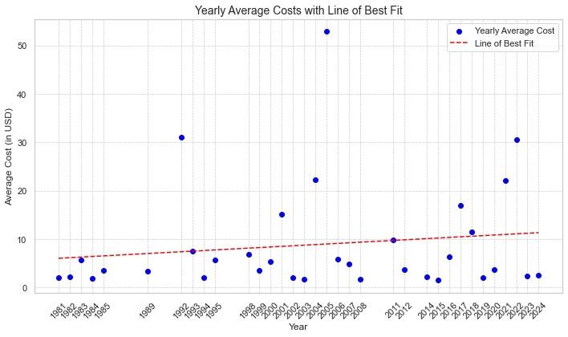

```python
plt.figure(figsize=(10, 6))
plt.scatter(decadal_avg['Start Year of Decade'], decadal_avg['Average Cost'], color='blue', label="Yearly Average Cost")

# Line of Best Fit
x = decadal_avg['Start Year of Decade']
y = decadal_avg['Average Cost']
coefficients = np.polyfit(x, y, deg=1)  # Fit a linear model
line_of_best_fit = np.poly1d(coefficients)
plt.plot(x, line_of_best_fit(x), color='red', linestyle='--', label="Line of Best Fit")

# Customizing the Plot
plt.title("Yearly Average Costs with Line of Best Fit", fontsize=14)
plt.xlabel("Year", fontsize=12)
plt.ylabel("Average Cost (in USD)", fontsize=12)
plt.xticks(decadal_avg['Start Year of Decade'], rotation=45)
plt.grid(True, linestyle='--', linewidth=0.7)
plt.legend()

# Show the Plot
plt.tight_layout()
plt.show()
```

What does this graph tell us?

```python
import pandas as pd

# Example data from scraping (replace with your actual scraped data)
data = {
    'End Date': filtered_dates,
    'Cost': filtered_costs
}

# Convert the data to a DataFrame
df = pd.DataFrame(data)

# Save the DataFrame to a CSV file
csv_file_path = 'scraped_data2.csv'
df.to_csv(csv_file_path, index=False)

print(f"Data successfully saved to {csv_file_path}")
```

```
Data successfully saved to scraped_data2.csv
```